# Citibike Trip Predictions with Linear Regression

Nikola Baci

6/17/2021

# Predict citibikes trips using Linear Regression

Read the file and examine its contents.

```r
trips_per_day <- read_tsv("trips_per_day.tsv")
head(trips_per_day, 10)
```

```
## # A tibble: 10 x 8
##    ymd        num_trips     date  prcp  snwd  snow  tmax  tmin
##    <date>         <dbl>    <dbl> <dbl> <dbl> <dbl> <dbl> <dbl>
##  1 2014-01-01      6059 20140101  0      0     0     3.3   2.4
##  2 2014-01-02      8600 20140102  0.33   0     3.1   3.3   1.8
##  3 2014-01-03      1144 20140103  0.29   5.9   3.3   1.8   0.9
##  4 2014-01-04      2292 20140104  0      5.9   0     2.9   0.8
##  5 2014-01-05      2678 20140105  0.14   3.9   0     4     2.7
##  6 2014-01-06      9510 20140106  0.36   1.2   0     5.5   1.9
##  7 2014-01-07      6267 20140107  0      0     0     1.9   0.4
##  8 2014-01-08      9246 20140108  0      0     0     2.2   0.9
##  9 2014-01-09     13354 20140109  0      0     0     3.2   2.2
## 10 2014-01-10      9847 20140110  0.11   0     0     3.7   3
```

```r
summary(trips_per_day)
```

```
##       ymd               num_trips          date               prcp
##  Min.   :2014-01-01   Min.   :  876   Min.   :20140101   Min.   :0.0000
##  1st Qu.:2014-04-02   1st Qu.:13119   1st Qu.:20140402   1st Qu.:0.0000
##  Median :2014-07-02   Median :23908   Median :20140702   Median :0.0000
##  Mean   :2014-07-02   Mean   :22138   Mean   :20140668   Mean   :0.1474
##  3rd Qu.:2014-10-01   3rd Qu.:31204   3rd Qu.:20141001   3rd Qu.:0.0600
##  Max.   :2014-12-31   Max.   :38619   Max.   :20141231   Max.   :4.9700
##       snwd             snow             tmax            tmin
##  Min.   : 0.000   Min.   : 0.000   Min.   :1.700   Min.   :0.400
##  1st Qu.: 0.000   1st Qu.: 0.000   1st Qu.:4.500   1st Qu.:3.500
##  Median : 0.000   Median : 0.000   Median :6.500   Median :5.000
##  Mean   : 1.033   Mean   : 0.137   Mean   :6.167   Mean   :4.733
##  3rd Qu.: 0.000   3rd Qu.: 0.000   3rd Qu.:7.800   3rd Qu.:6.300
##  Max.   :18.100   Max.   :11.000   Max.   :9.200   Max.   :7.700
```

```r
nrow(trips_per_day)
```

```
## [1] 365
```

Let’s add to this table a couple of other columns that might help us in out predictions.

```r
trips_per_day <- mutate(trips_per_day, day_of_week = wday(ymd))
trips_per_day <- mutate(trips_per_day,
                        day_of_week=factor(day_of_week, levels=c(1,2,3,4,5,6,7),
                                           labels=c("Sunday", "Monday","Tuesday","Wednesday", "Thursday", "Friday", "Saturday")))
trips_per_day <- mutate(trips_per_day,
                        work_day = factor(day_of_week,
                                           levels=c("Sunday", "Monday","Tuesday","Wednesday", "Thursday", "Friday", "Saturday"),
                                           labels=c(0,1,1,1,1,1,0)))

holidays <- read.delim("holiday.txt", sep=",")
holidays <- mutate(holidays, date = as.Date(holidays$date))
holidays <- filter(holidays, date >= "2014-01-01", date <= "2014-12-31") %>%
  select(-row)

trips_per_day <- left_join(trips_per_day, holidays, by= c("ymd" = "date"))

trips_per_day$holiday[! is.na(trips_per_day$holiday)] <- 1
trips_per_day$holiday[is.na(trips_per_day$holiday)] <- 0


trips_per_day <- mutate(trips_per_day, did_not_snow = 1 - as.integer(trips_per_day$snwd > 5))
trips_per_day <- mutate(trips_per_day, did_not_rain = 1 -as.integer(trips_per_day$prcp > 1))
```

Now the table is composed of the following columns:

1. ymd: year-month-day
2. num_trips: the number of trips for the given day in ymd column
3. data: an integer version of ymd column
4. prcp: precipitation level on the give date of type Double
5. snwd: snow depth on the given day of type Double
6. snow: snow level on the given day of type Double ??
7. tmax: the max temperature on the given day
8. tmin: the min temperature on the given day
9. day_of_week: label of the days Monday through Sunday
10. work_day: indicating if the day is a Monday to Friday (0=weekend)
11. holiday: indicating if the day is a holiday or not (0=not holiday)
12. did_not_snow: indicating if it snowed or not (0=snow)
13. did_not_rain: indicating if it rained or not (0=rained)

Proceed to split the data into train, validation and test set with ratio 8:1:1. We will train the model on the train set, verify its correctness on the validation set, and finally we will test the model on the test set.

```r
set.seed(42)

num_days <- nrow(trips_per_day)
days <- c(1:num_days)

frac_train <- 0.8
frac_validation <- 0.1


num_train <- floor(frac_train * num_days)
num_validation <- floor(frac_validation * num_days)

train_data <- sample(days, num_train, replace = FALSE)
trips_per_day_train <- trips_per_day[train_data, ]

days <- days[! days %in% train_data]
validation_data <- sample(days, num_validation, replace = FALSE)
trips_per_day_validation <- trips_per_day[validation_data, ]

days <- days[! days %in% validation_data]
test_data <- days
trips_per_day_test <- trips_per_day[test_data, ]
```

## Trying Different Models

Here we will use the tmin to make prediction on the number of trips each day and we will test on different degrees of polynomial functions.

For each degree we record the train error and the validation error. Plot these records and see the lowest vallay in the graph, that represents the degree we should choose.

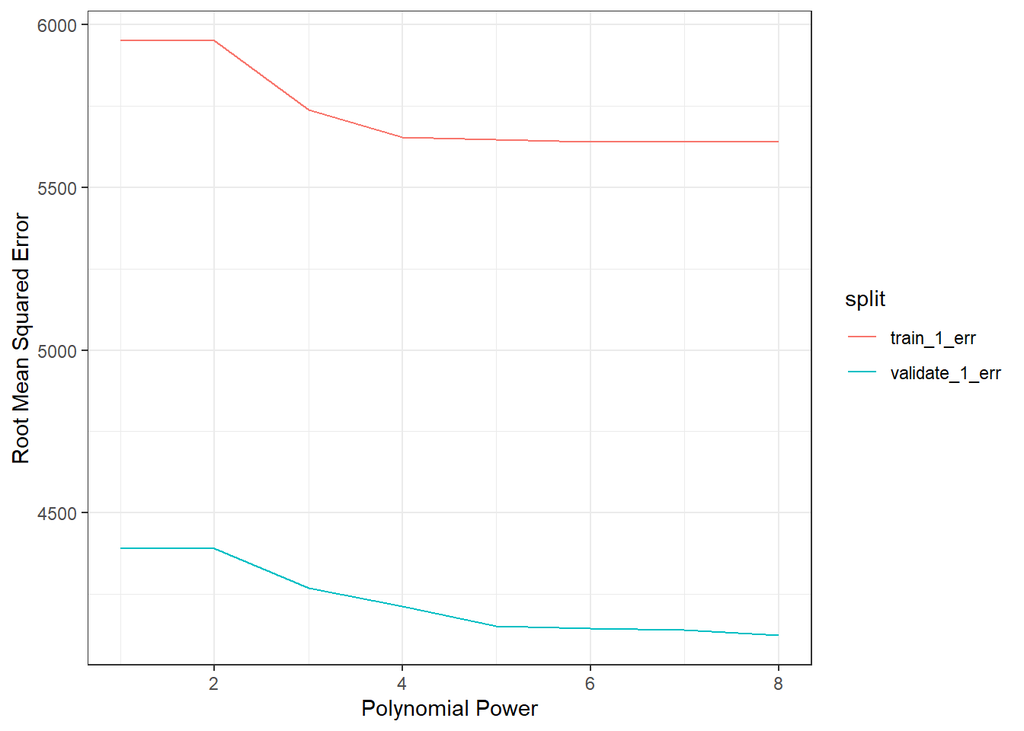

```r
K <- 1:8
train_1_err <- c()
validate_1_err <- c()
for(k in K){
        model <- lm(num_trips ~ poly(tmin, k, raw = T), data = trips_per_day_train)
        train_1_err[k] <- sqrt(mean((predict(model, trips_per_day_train) - trips_per_day_train$num_trips)^2))
        validate_1_err[k] <- sqrt(mean((predict(model, trips_per_day_validation) - trips_per_day_validation$num_trips)^2))
}

plot_data_1_err <- data.frame(K, train_1_err, validate_1_err)

plot_data_1_err <- data.frame(K, train_1_err, validate_1_err) %>%
  gather("split", "error", -K)

plot_data_1_err %>%
        ggplot() +
        geom_line(aes(x = K, y = error, color = split))+
        xlab("Polynomial Power")+
        ylab("Root Mean Squared Error")
```

After choosing the degree, we plot the data and see how our regression model fit the data.

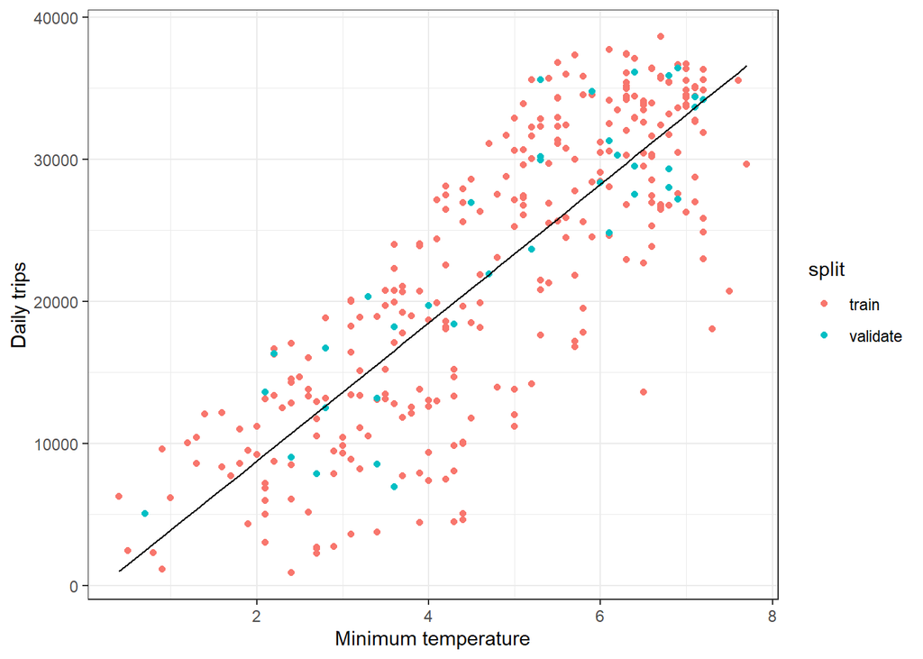

```r
model_1 <- lm(num_trips ~ poly(tmin, 2, raw = T), data = trips_per_day_train)

trips_per_day_train_1 <- trips_per_day_train %>%
  add_predictions(model_1) %>%
  mutate(split = "train")

trips_per_day_validation_1 <- trips_per_day_validation %>%
  add_predictions(model_1) %>%
  mutate(split = "validate")

plot_data_1 <- bind_rows(trips_per_day_train_1, trips_per_day_validation_1)

plot_data_1 %>%
ggplot(aes(x = tmin, y = num_trips)) +
  geom_point(aes(color = split)) +
  geom_line(aes(y = pred)) +
  xlab('Minimum temperature') +
  ylab('Daily trips')
```

```r
column_names <- c("prcp", "snwd", "snow", "tmin", "tmax")

correlation_coef <- c()
k <- 1
for(col in column_names){
  correlation_coef[k] <- cor(x=trips_per_day_train$num_trips, y=trips_per_day_train[[col]])
  k <- k+1
}

correlation_coef
```

```
## [1] -0.2882594 -0.4899736 -0.2862745  0.8182211  0.8417636
```

## Let’s test models of multivariables

In the next couple of code chunks we experiment with different formulas for out regression model. Then we put the prediction in the validation table that corresponds to that model, and finally I plot the results and analyze the performance of the model.

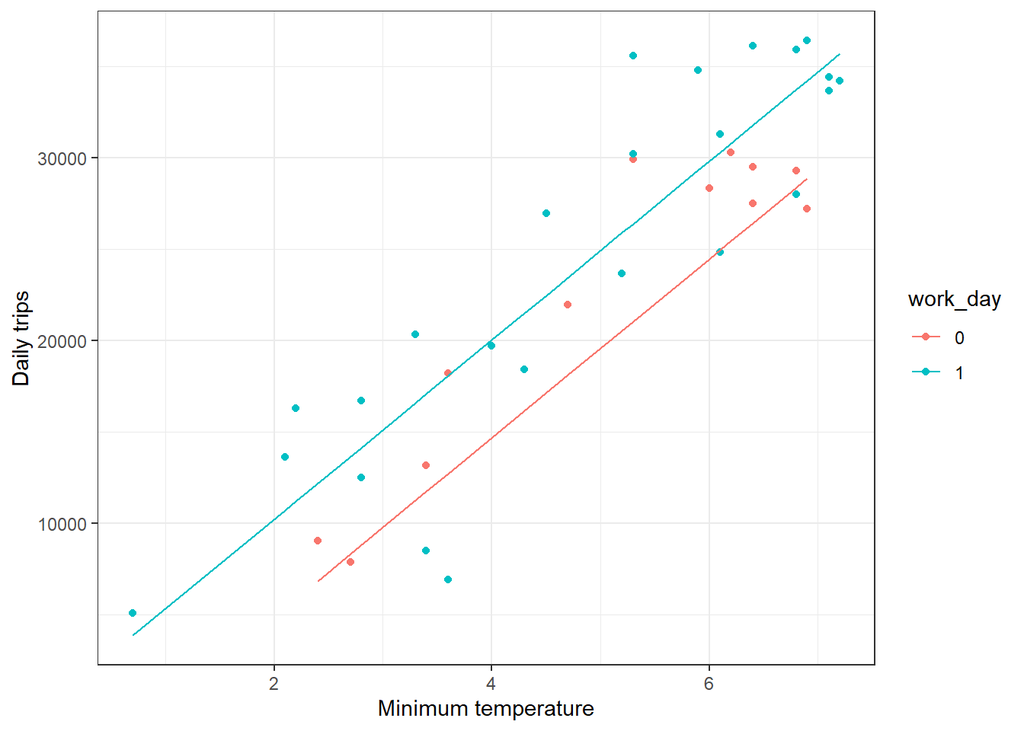

```r
#fit the model
model_2 <- lm(num_trips ~ tmin + work_day, data = trips_per_day_train)

#create a new validation table that will contain the predictions of the model
trips_per_day_validation_2 <- trips_per_day_validation %>%
  add_predictions(model_2)

#plot the regression line and the actual values
trips_per_day_validation_2 %>%
ggplot(aes(x = tmin, y = num_trips, color = work_day)) +
  geom_point(aes(y = num_trips)) +
  geom_line(aes(y = pred)) +
  xlab('Minimum temperature') +
  ylab('Daily trips')
```

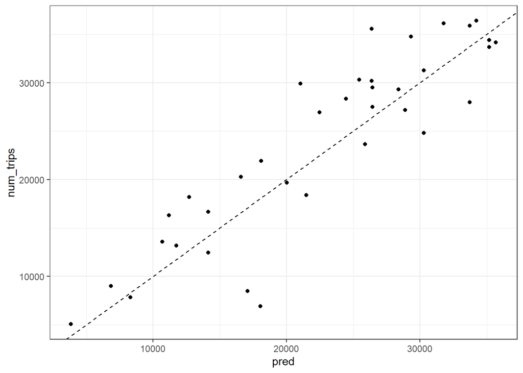

```r
#plot the prediction and actual values
trips_per_day_validation_2 %>%
  ggplot()+
  geom_point(aes(x = pred, y = num_trips))+
  geom_abline(linetype = "dashed")
```

Let’s see how a small change in the formula, could change our Root Mean Square Error(RMSE). The results below, do not show a significant change.

```r
model_3 <- lm(num_trips ~ tmin * work_day, data = trips_per_day_train)

model_2_err <- sqrt(mean((predict(model_2, trips_per_day_validation) - trips_per_day_validation$num_trips)^2))
model_3_err <- sqrt(mean((predict(model_3, trips_per_day_validation) - trips_per_day_validation$num_trips)^2))
cat("model 2 error:", model_2_err,"\n")
```

```
## model 2 error: 4410.137
```

```r
cat("model 3 error:", model_3_err,"\n")
```

```
## model 3 error: 4409.96
```

Try a different formula for the model. With this model we seem to have a lower prediction error.

```r
model_5 <- lm(num_trips ~ (tmax + I(tmax^2))*work_day, data = trips_per_day_train)

model_5_err <- sqrt(mean((predict(model_5, trips_per_day_validation) - trips_per_day_validation$num_trips)^2))
cat("model 5 error:", model_5_err,"\n")
```

```
## model 5 error: 3750.617
```

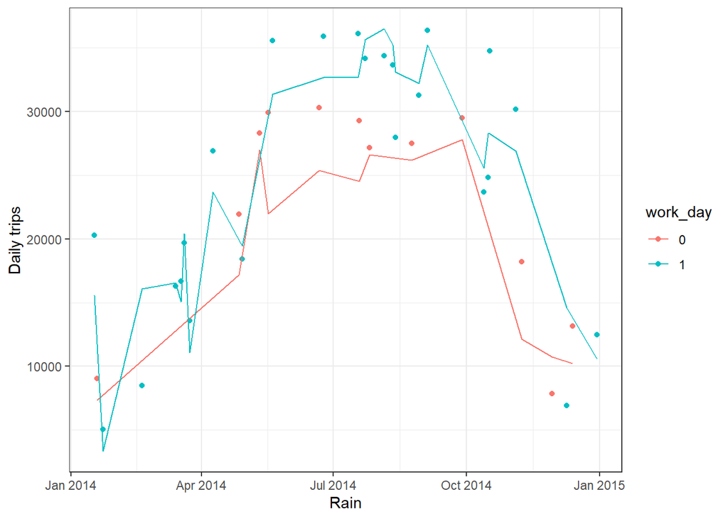

```r
trips_per_day_validation_5 <- trips_per_day_validation %>%
  add_predictions(model_5)

trips_per_day_validation_5 %>%
  ggplot(aes(x = ymd, y = num_trips, color = work_day)) +
  geom_point(aes(y = num_trips)) +
  geom_line(aes(y = pred)) +
  xlab('Rain') +
  ylab('Daily trips')
```

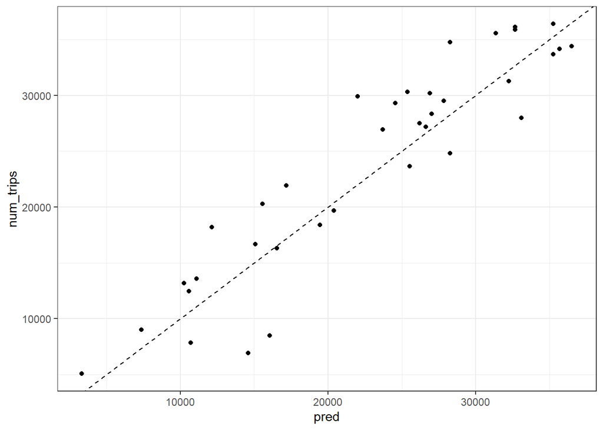

```r
trips_per_day_validation_5 %>%
  ggplot()+
  geom_point(aes(x = pred, y = num_trips))+
  geom_abline(linetype = "dashed")
```

## Final Model

After experimenting with a number of formulas for the regression model, I decided to go with this model. This model performed better on the validation set the the other models I tried.

```r
model_6 <- lm(num_trips ~ (tmax + I(tmax^2)) + work_day + did_not_rain*did_not_snow, data = trips_per_day_train)

model_6_err <- sqrt(mean((predict(model_6, trips_per_day_validation) - trips_per_day_validation$num_trips)^2))
cat("model 6 error:", model_6_err,"\n")
```

```
## model 6 error: 3414.645
```

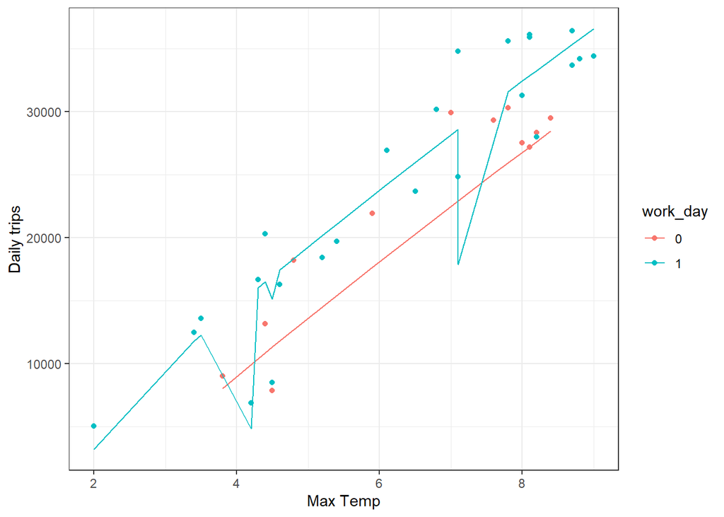

```r
trips_per_day_validation_6 <- trips_per_day_validation %>%
  add_predictions(model_6)


trips_per_day_validation_6 %>%
  ggplot(aes(x = tmax, y = num_trips, color = work_day)) +
  geom_point(aes(y = num_trips)) +
  geom_line(aes(y = pred)) +
  xlab('Max Temp') +
  ylab('Daily trips')
```

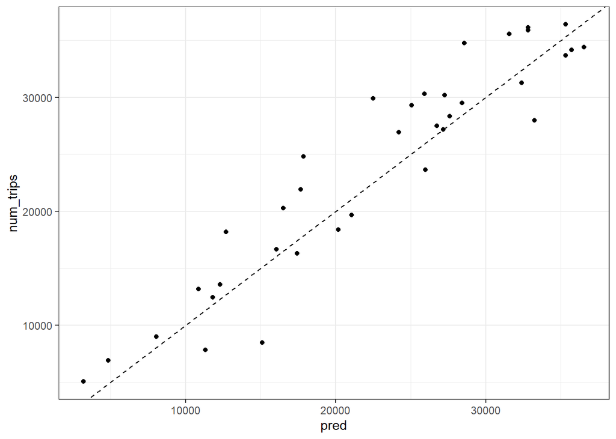

```r
trips_per_day_validation_6 %>%
  ggplot()+
  geom_point(aes(x = pred, y = num_trips))+
  geom_abline(linetype = "dashed")
```

## Save the model

Let’s save the model and all the objects needed to perform remote testing of the model. Also, in the .RData I included two graphs that show the trends between prediction and the actual values.

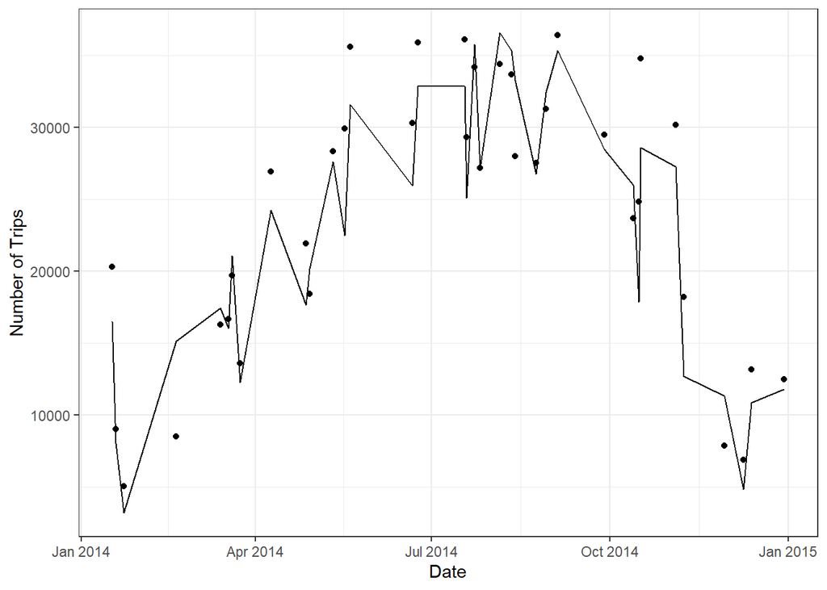

```r
date_count_plot <- trips_per_day_validation_6 %>%
  ggplot() +
  geom_line(aes(x = ymd, y = pred)) +
  geom_point(aes(x = ymd, y = num_trips)) +
  xlab("Date") +
  ylab("Number of Trips")

actual_vs_pred_plot <- trips_per_day_validation_6 %>%
  ggplot()+
  geom_point(aes(x = pred, y = num_trips))+
  geom_abline(linetype = "dashed")

date_count_plot
```

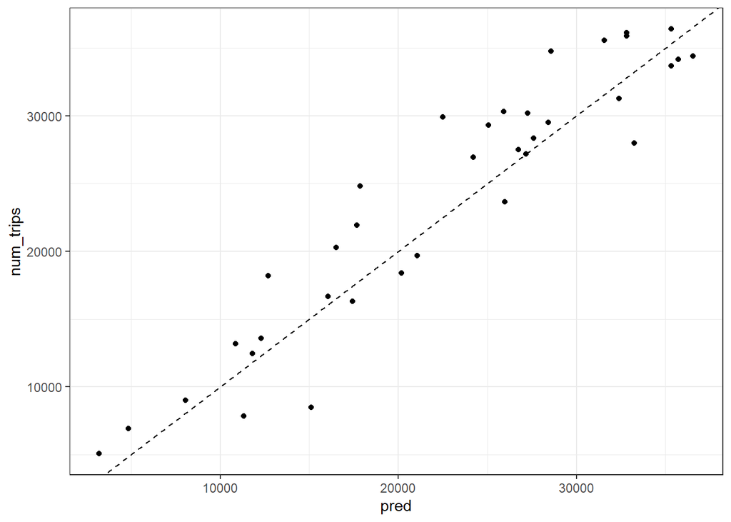

```r
actual_vs_pred_plot
```

```r
save(trips_per_day, trips_per_day_train, trips_per_day_validation, trips_per_day_test, model_6, date_count_plot, actual_vs_pred_plot, file = "predict_citibike.RData")
```

## The moment of truth

After picking what seemed to be the best model for prediction for the num_trips, we finally use this model to make prediction on the test data.

```r
trips_per_day_test <-  trips_per_day_test %>%
  add_predictions(model_6)

pred_error <- sqrt(mean((predict(model_6, trips_per_day_test) - trips_per_day_test$num_trips)^2))
cat("final model error:", pred_error,"\n")
```

```
## final model error: 4429.327
```

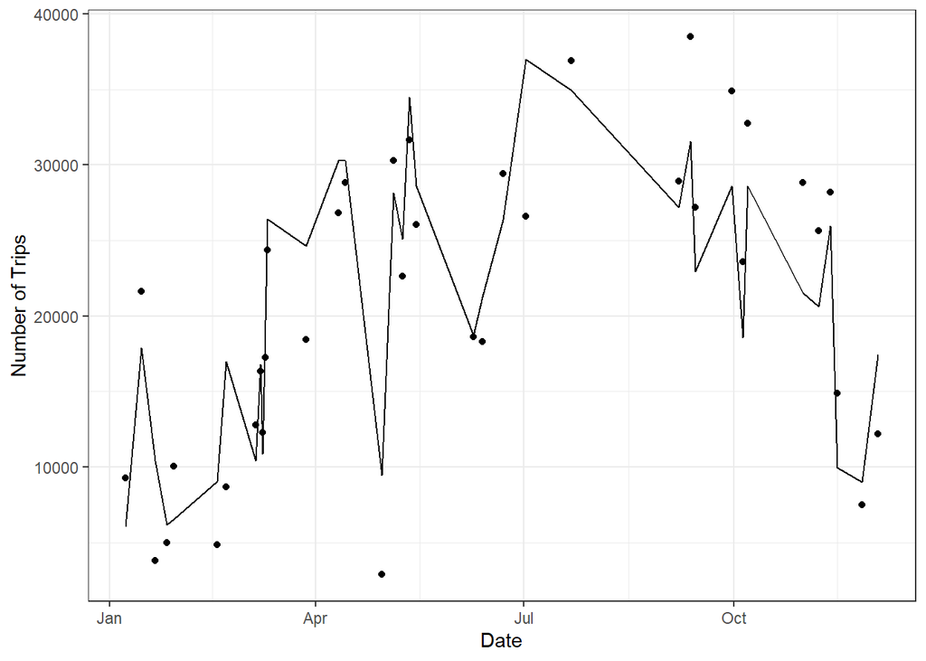

```r
trips_per_day_test %>%
  ggplot() +
  geom_line(aes(x = ymd, y = pred)) +
  geom_point(aes(x = ymd, y = num_trips)) +
  xlab("Date") +
  ylab("Number of Trips")
```

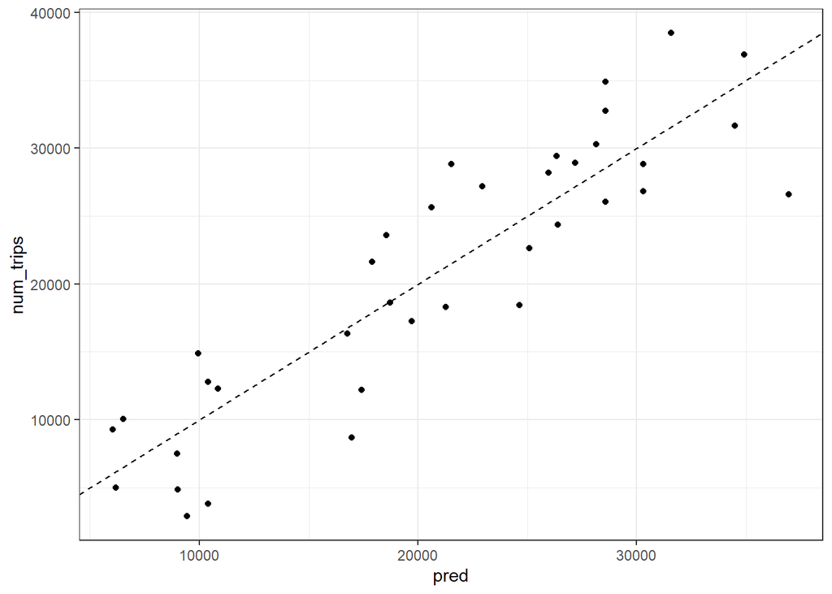

```r
trips_per_day_test %>%
  ggplot()+
  geom_point(aes(x = pred, y = num_trips))+
  geom_abline(linetype = "dashed")
```

## Conclusions:

The model did not perform as I expected on the test dataset. The RMSE is higher than the validation error. This could be dues to external factors such as chance or to the lack of sufficient number of observations.Another reason the model did not perform as I expected could be the choice of the formula and the variables used on this formula.

It is hard to say how this model will perform on future data, but I am optimistic that it will be the same as now or a bit better. The reason I say so is because the model is taking into consideration a number of important factors such as the day of the week and the weather that greatly effect the day-to-day number of rides.